# Point Process

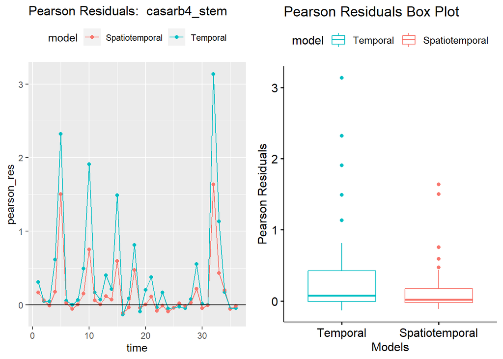

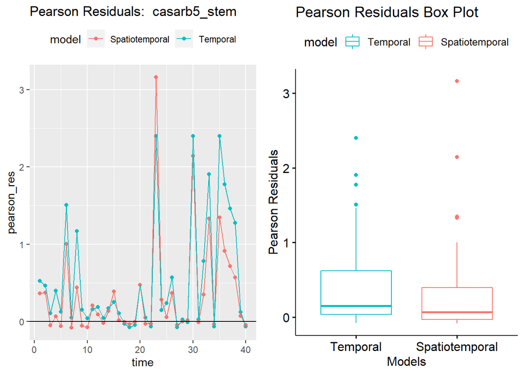

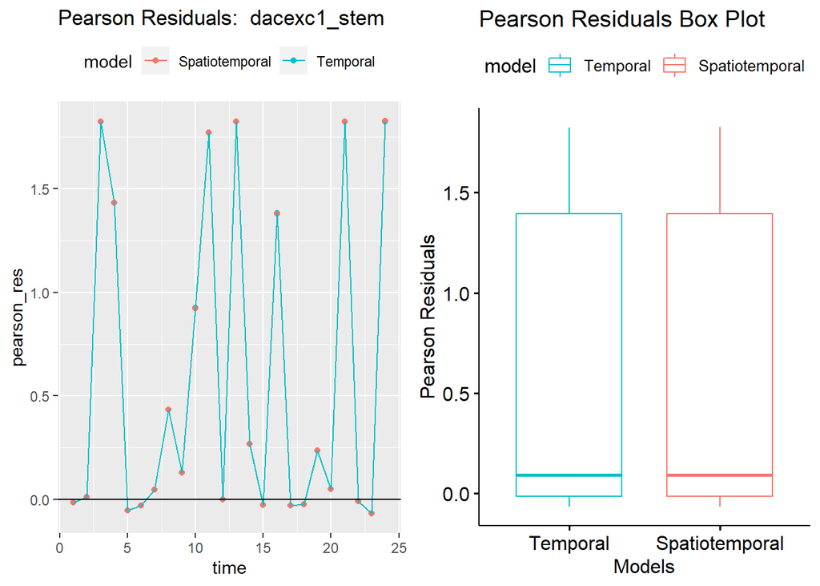

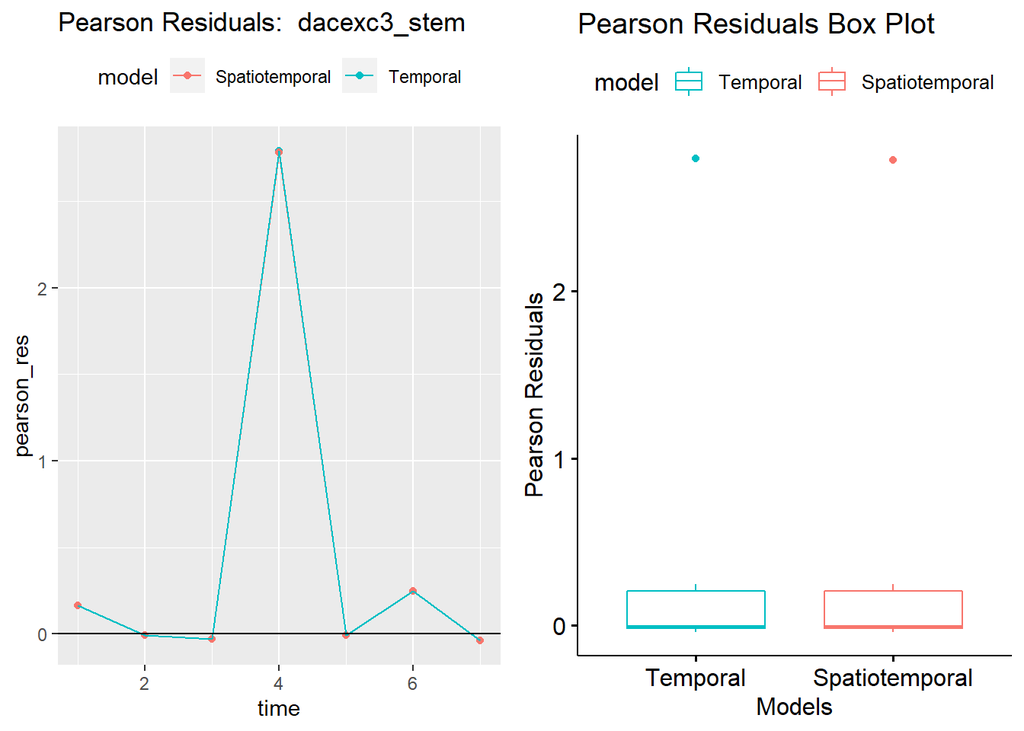

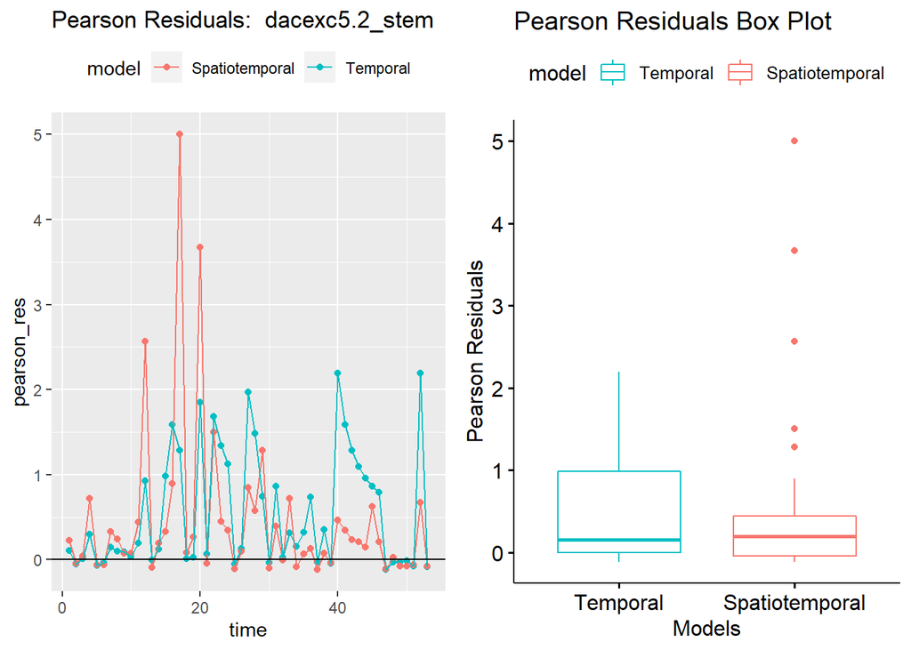

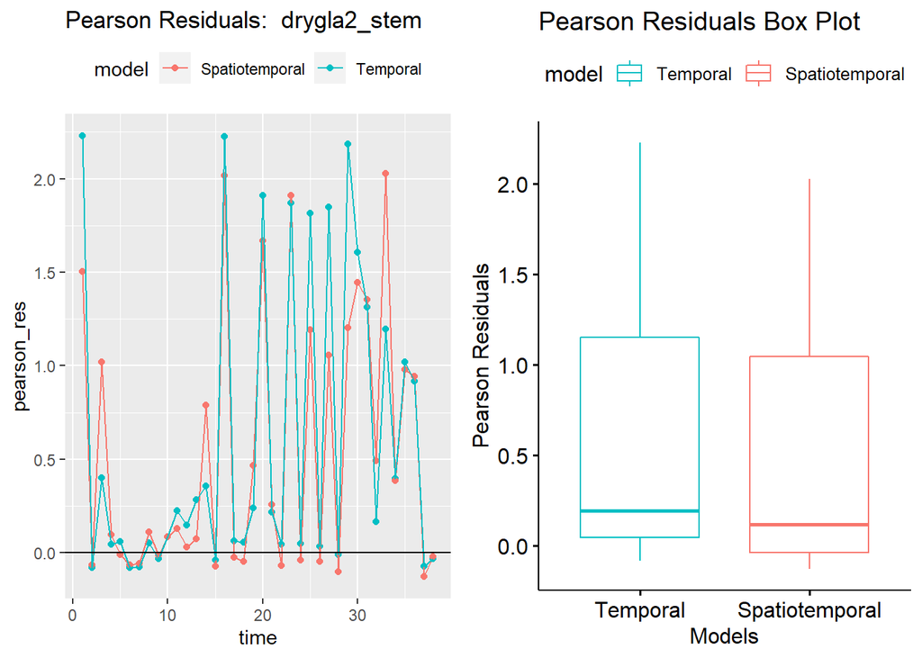

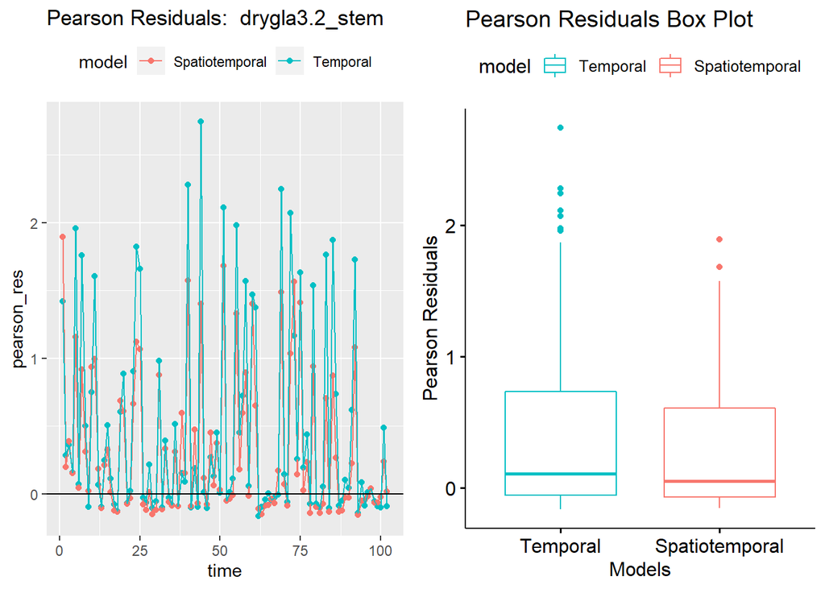

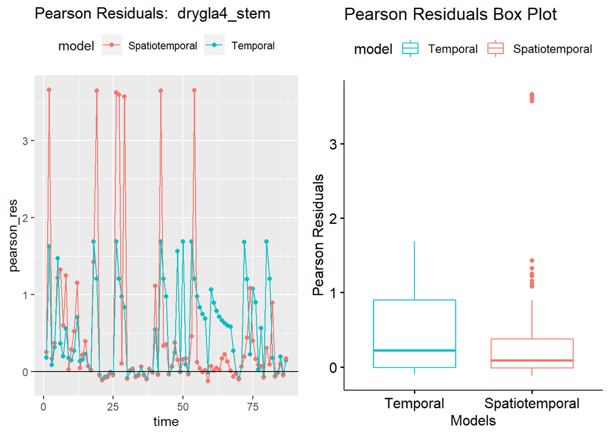

[16 more figures not shown]

Change in P-values of Paired T-test (Temporal vs Spatial-Temporal Hawkes Process)

|  | folder_index | species | est_mean | std_err | two_sided_p_val | one_sided_p_val |
| --- | --- | --- | --- | --- | --- | --- |
| alclat2_stem | 1.00 | 1.00 | 0.14 | 0.07 | 0.03 | 0.02 |
| alclat4_stem | 2.00 | 1.00 | -0.00 | 0.00 | 0.00 | 1.00 |
| alclat5.2_stem | 3.00 | 1.00 | -0.00 | 0.00 | 0.01 | 0.99 |
| casarb2.2_stem | 4.00 | 2.00 | 0.13 | 0.04 | 0.00 | 0.00 |
| casarb4_stem | 5.00 | 2.00 | 0.23 | 0.06 | 0.00 | 0.00 |
| casarb5_stem | 6.00 | 2.00 | 0.17 | 0.05 | 0.00 | 0.00 |
| dacexc1_stem | 7.00 | 3.00 | -0.00 | 0.00 | 0.40 | 0.80 |
| dacexc3_stem | 8.00 | 3.00 | 0.00 | 0.00 | 0.36 | 0.18 |
| dacexc5.2_stem | 9.00 | 3.00 | 0.11 | 0.11 | 0.32 | 0.16 |
| drygla2_stem | 10.00 | 4.00 | 0.06 | 0.05 | 0.30 | 0.15 |
| drygla3.2_stem | 11.00 | 4.00 | 0.16 | 0.03 | 0.00 | 0.00 |
| drygla4_stem | 12.00 | 4.00 | 0.01 | 0.09 | 0.88 | 0.44 |
| drygla5_stem | 13.00 | 4.00 | 0.09 | 0.07 | 0.20 | 0.10 |
| inglau1_stem | 14.00 | 5.00 | 0.08 | 0.04 | 0.04 | 0.02 |
| inglau2_stem | 15.00 | 5.00 | 0.16 | 0.05 | 0.00 | 0.00 |
| inglau3_stem | 16.00 | 5.00 | 0.14 | 0.12 | 0.25 | 0.13 |
| inglau4_stem | 17.00 | 5.00 | 0.01 | 0.00 | 0.00 | 0.00 |
| inglau5_stem | 18.00 | 5.00 | 0.00 | 0.00 | 0.18 | 0.09 |
| micguy1_stem | 19.00 | 6.00 | -0.01 | 0.01 | 0.34 | 0.83 |
| micguy2_stem | 20.00 | 6.00 | 0.16 | 0.07 | 0.02 | 0.01 |
| micguy3_stem | 21.00 | 6.00 | 0.29 | 0.13 | 0.03 | 0.01 |
| micguy3b_stem | 22.00 | 6.00 | -0.17 | 0.16 | 0.31 | 0.85 |
| micguy4_stem | 23.00 | 6.00 | 0.13 | 0.04 | 0.00 | 0.00 |
| micguy5_stem | 24.00 | 6.00 | 0.00 | 0.00 | 0.15 | 0.08 |
| ocoleu1_stem | 25.00 | 7.00 | 0.10 | 0.07 | 0.17 | 0.08 |
| ocoleu2_stem | 26.00 | 7.00 | -0.00 | 0.00 | 0.00 | 1.00 |
| slober3_stem | 27.00 | 8.00 | 0.07 | 0.02 | 0.00 | 0.00 |
| tabhet1.2_stem | 28.00 | 9.00 | 0.11 | 0.07 | 0.14 | 0.07 |

If p-value > 0.05 for two-sided paired t-test (highlighted in blue), we fail to reject the null hypothesis that the pearson residuals of two models are not statistically significantly different.

If p-value <= 0.05 for one-sided paired t-test (highlighted in green), we reject the null hypothesis that the pearson residuals of temporal Hawkes process is smaller than that of spatiotemporal model.

If both estimated mean difference and standard deviation are close to 0 (rounded to zero in the table because absolute value < 0.005), it means the pearson residuals are roughly the same for 2 models, they’re highlighted in lightblue.

In short, blue implys where two models perform similarly, and green are for cases where spatiotemporal outperforms temporal Hawkes process model.

TODO: Pearson Residual for STHP Deviance Residual?(ref:RESIDUAL ANALYSIS METHODS FOR SPACE-TIME POINT PROCESSES 4.3) or R test? (ref:Assessment of Point Process Models for Earthquake Forecasting)